# Final_project

YiranZ

2025-05-01

# 4B Movement in America: Is It a Real Thing?

This page displays my results on 4B movement in North America.

The 4B movement is a radical feminist movement that originated in South Korea between 2017 to 2019. It advocates for four principles: no date, no sex, not childbirth, and no marriage with men. This movement aims to reject traditional gender roles and to challenge the patriarchal culture.

In this project, I aim to explore the 4B movement in the English-speaking world, particularly in American.

My key research questions are:

1. How is the 4B movement reported by mainstream media?
2. What are participants of the 4B movement discussing in online spaces?

## Data & Trend

I used data from newspaper articles and reddit discussions. The final sample size for newspapers is 242, while the final sample size for online posts is 6773.

### Trends of Newspaper

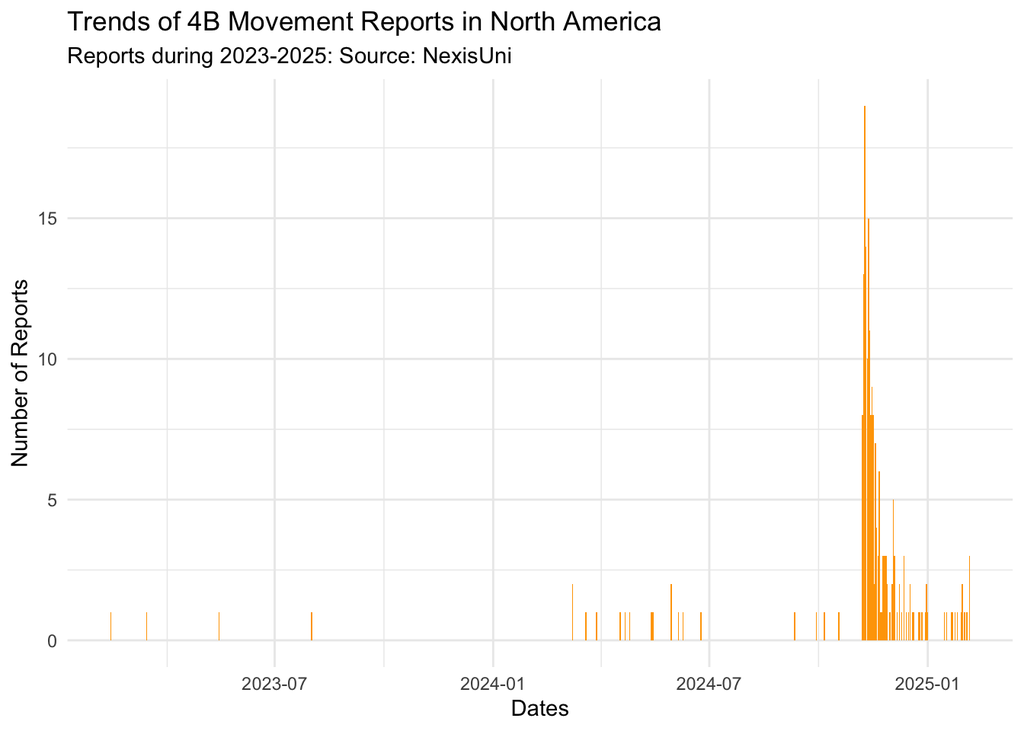

Most of the articles were published during the presidential election period.

About 5 to 15 articles each day during the election period.

### Trends of Social Media

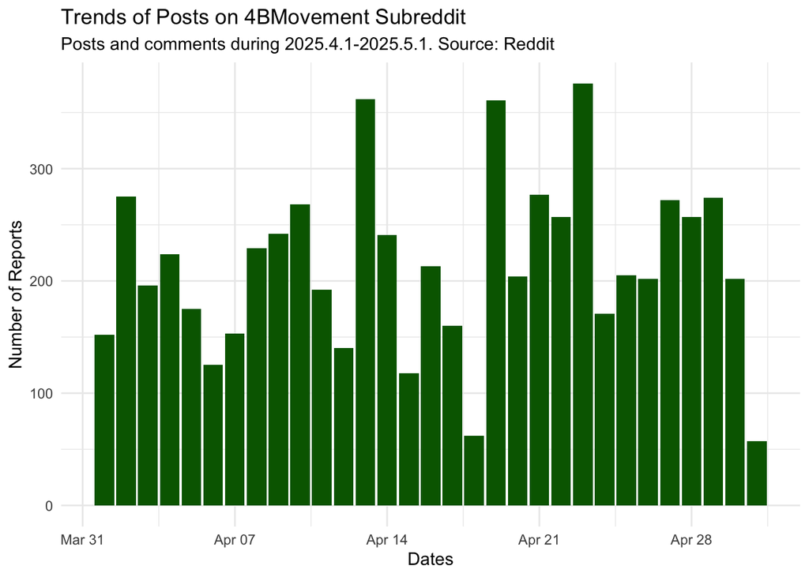

## Tokenize & Bigrams

### Bigrams from Newspapers

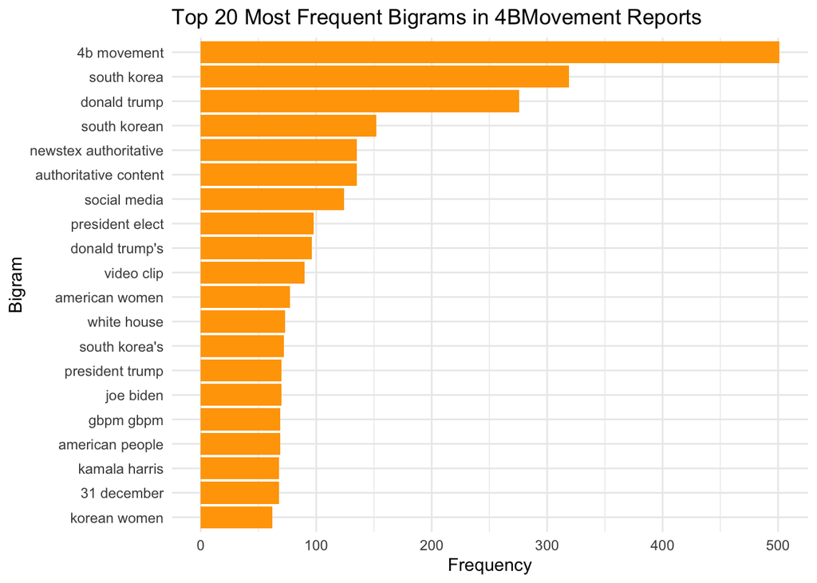

### Bigrams from Social Media

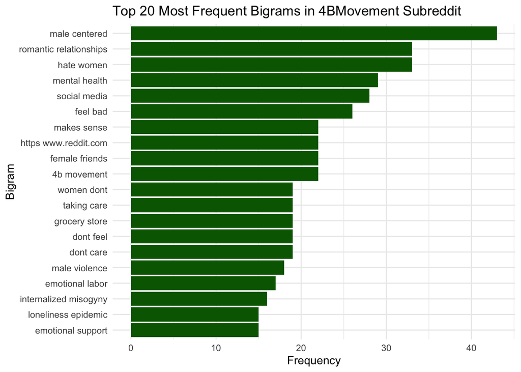

## KWIC

#### KWIC with Newspapers

Based on the top 20 bigrams from newspaper reports, the “4B movement” and “Donald Trump” are the most common themes. So, I examined the adjectives surrounding these words using KWIC.

##### Word Cloud for 4B movement

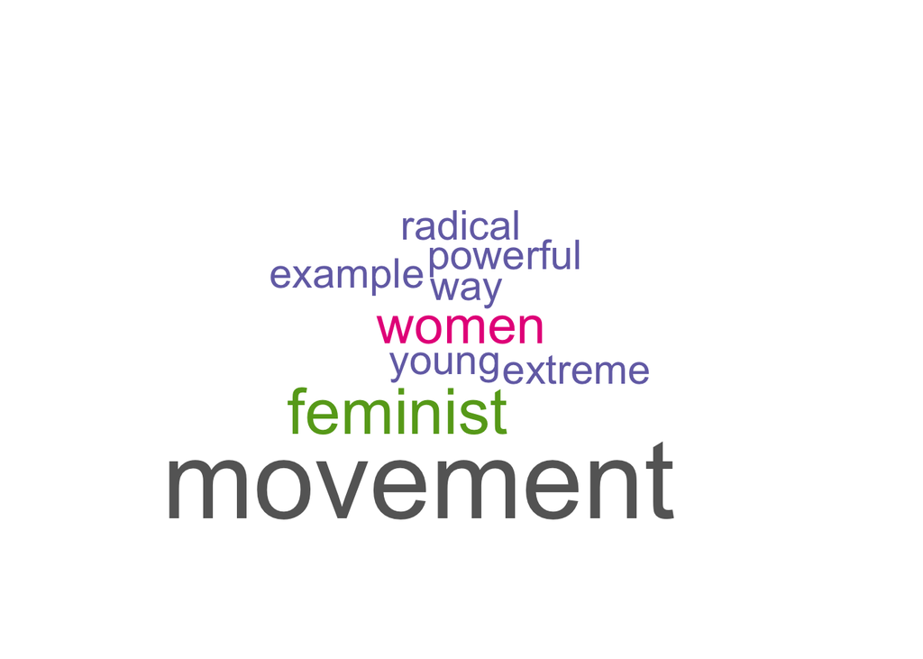

##### Word Cloud for Donald Trump

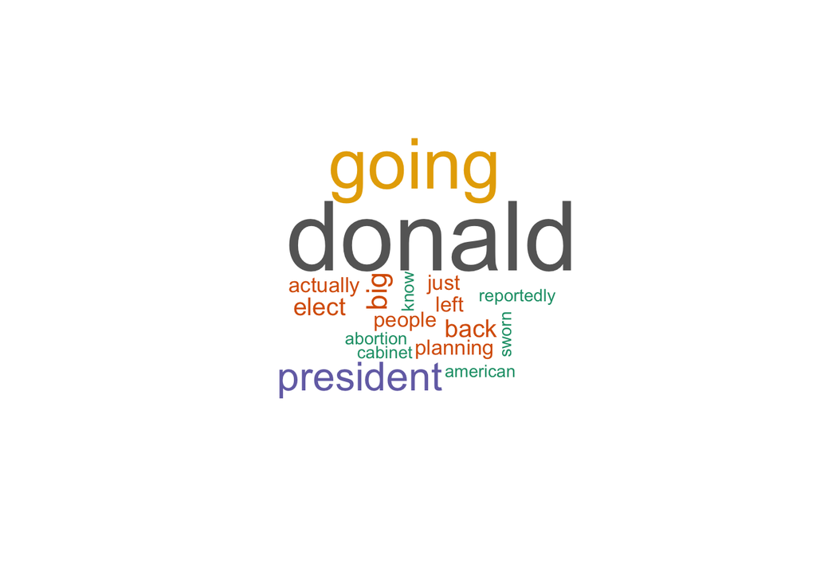

One sentence summary: Trump is back, while the 4B Movement is feminist and extreme.

#### KWIC with Reddits

Based on the top 20 bigrams from Reddit discussions, “men” and “relationships” are common topics. Therefore, I examined the use of adjectives surrounding these two themes

##### Word Cloud for Men

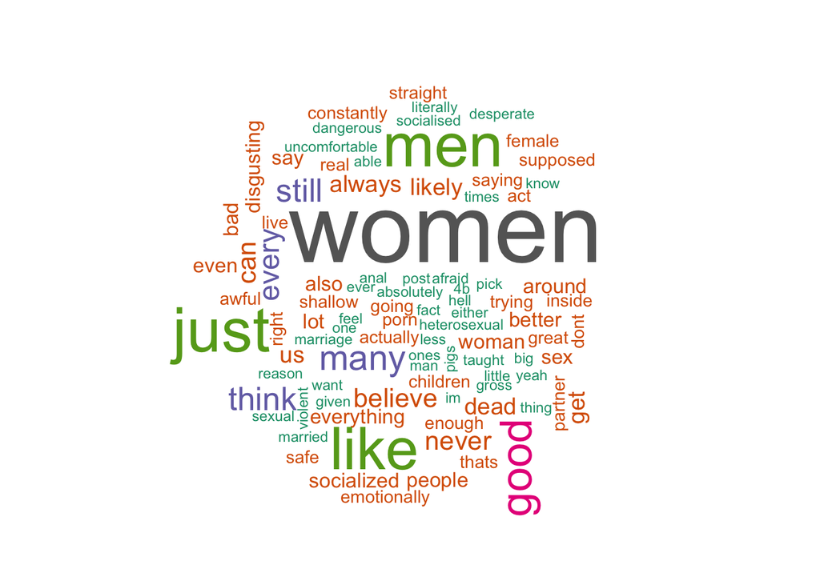

##### Word Cloud for Relationships & Marriage

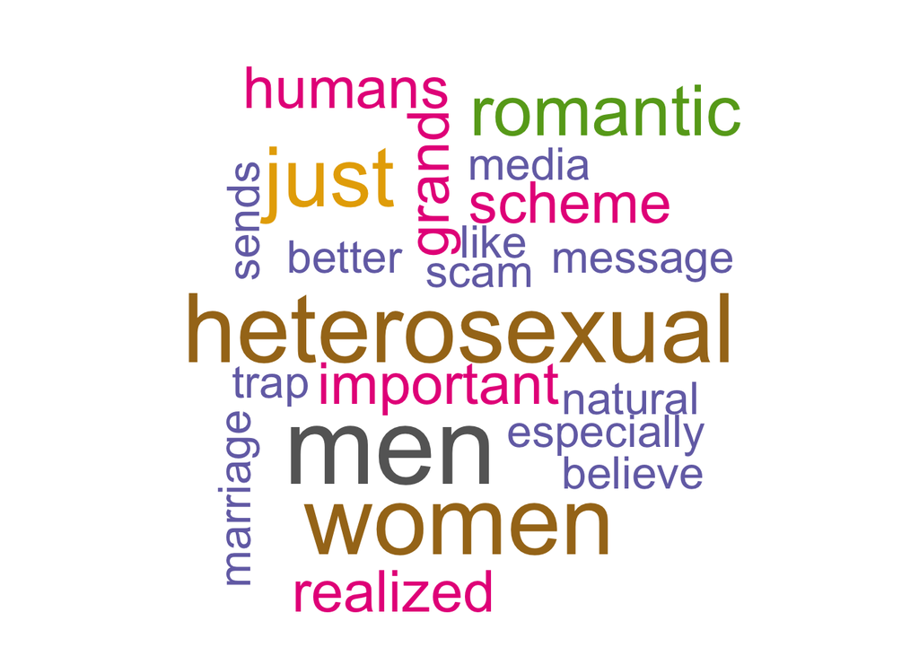

One sentence summary: men are violent and unattractive, and marriage and romantic relationships are a trap and unimportant.

## Content Analysis & Sentiment Analysis

#### Sentiment Analysis for Newspaper

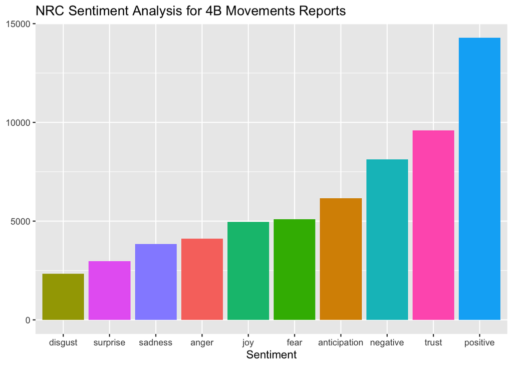

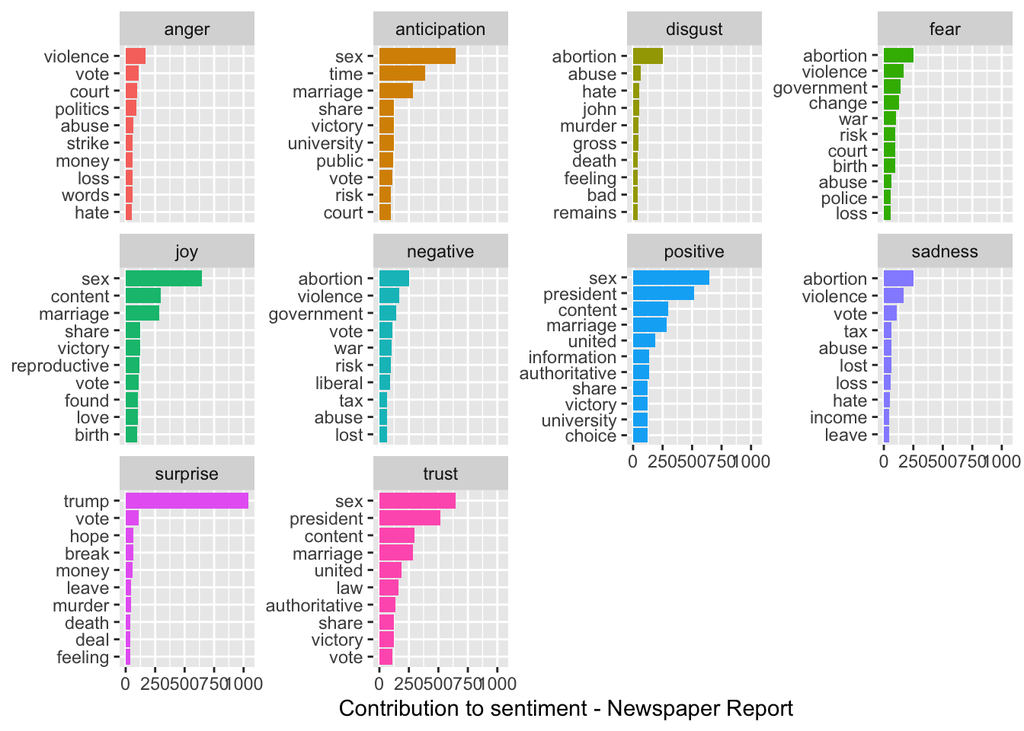

#### Sentiment Analysis for Reddit Discussions

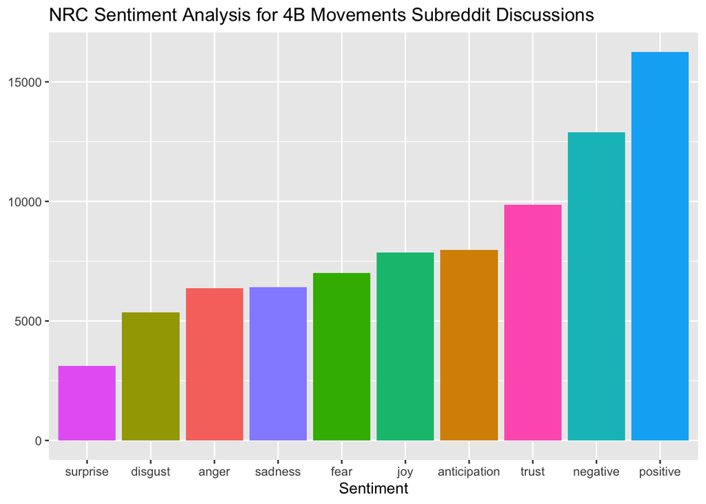

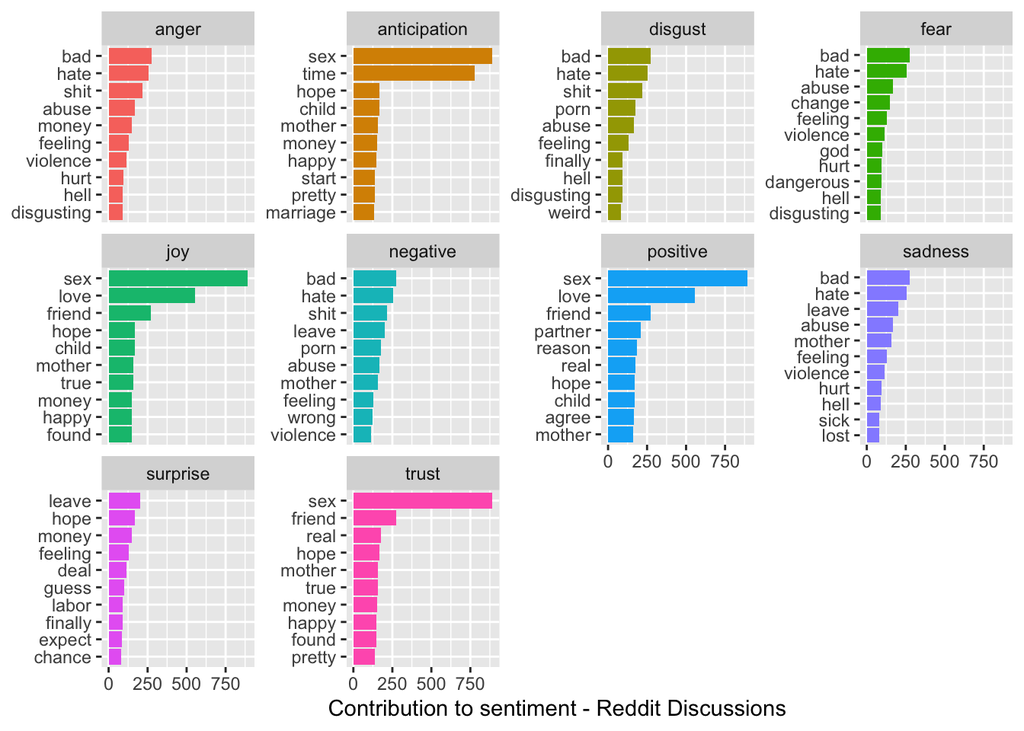

Both the sentiment analysis of news reports and online discussions, “positive” is the most common sentiment overall. But to be honest, I’m not entirely sure how much I can trust that result. For instance, the word sex is categorized as positive and is linked to joy in the NRC lexicon. However, when I actually read those posts and articles, sex doesn’t seem to be talked about in a joyful way.

So, to explore deeper, I used KWIC with word cloud to see what kinds of words were typically associated with sex. The result is below:

##### Word Cloud for Sex in Newspapers

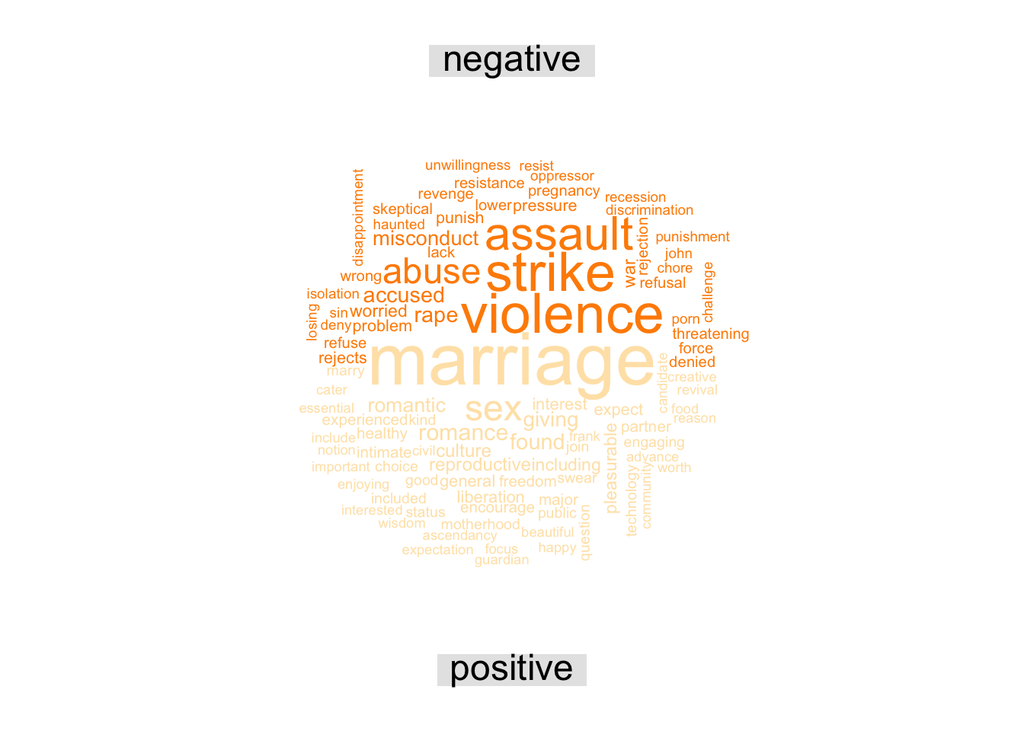

##### Word Cloud for Sex in Reddit

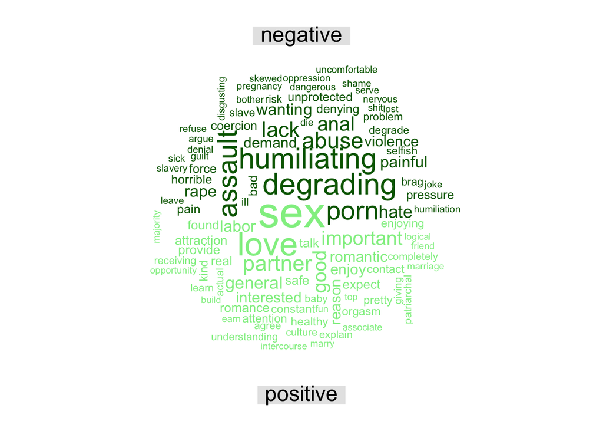

Based on the two word clouds with sentimence, it’s clear that sex is definitely not being discussed in a very positive way. Instead, it were considered as humiliating and degrading for women and were connected with sexual abuse, sexual assault, and sexual strike. Thus, I think it is fair to say that the sentiment analysis overestimate the positive sentiment of those articles and online discussions.

###### However the negative?

For sentiment analysis of the negative sentiment, the common words for newspapers are hate, violence, abuse, abortion, murder, strike. While the common negative words for reddit posts are hate, abuse, violence, porn.

##### Quotes from Reddit: violence and hate

“ I don’t hate men the same way men hate women. ”

“ When women say they hate men, they want nothing to do with them. ”

“ What you’re describing isn’t the hatred of men but the violence and sexism you have received from men. ”

“ A world where we are never truly safe from male violence. ”

“ Decentering them does not exclude us from their violence. We need to keep ourselves safe. ”

Based on my observation, the negative sentiment analysis turned out to be more accurate for this analysis.

I think this is because the 4B movement is trying to deconstruct and redefine what marriage, romantic relationships, and sex actually mean. In traditional culture, these things are usually seen as desirable and normal, and men are often viewed as strong, dominant, and the first gender. But within 4B discourse, these ideas are flipped. They’re reframed as symbols of patriarchy, as an exploitation or oppression of women, and as something harmful or unattractive.

## Topic Model

I identified six topics for each data source.

#### Topic model for Newspaper Reports

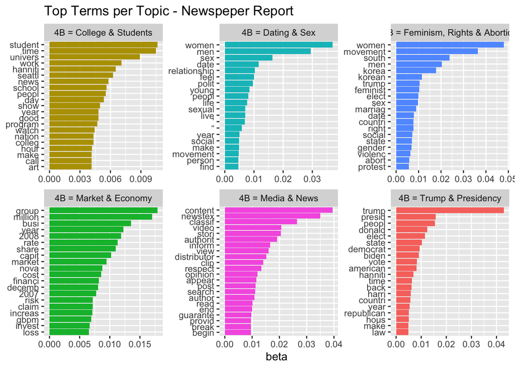

I found that most of the reports related to the 4B movement focus on the broader context of America. Four of the topics are about the background: the political environment (especially the presidential election and Trump’s victory), the economy and market conditions, the college and students, and the media and news.

The other two topics talked about the substance of the 4B movement itself. That is, the rejection of sex and dating, and American feminist women’s reaction to abortion laws.

#### Topic model for Reddit Discussions

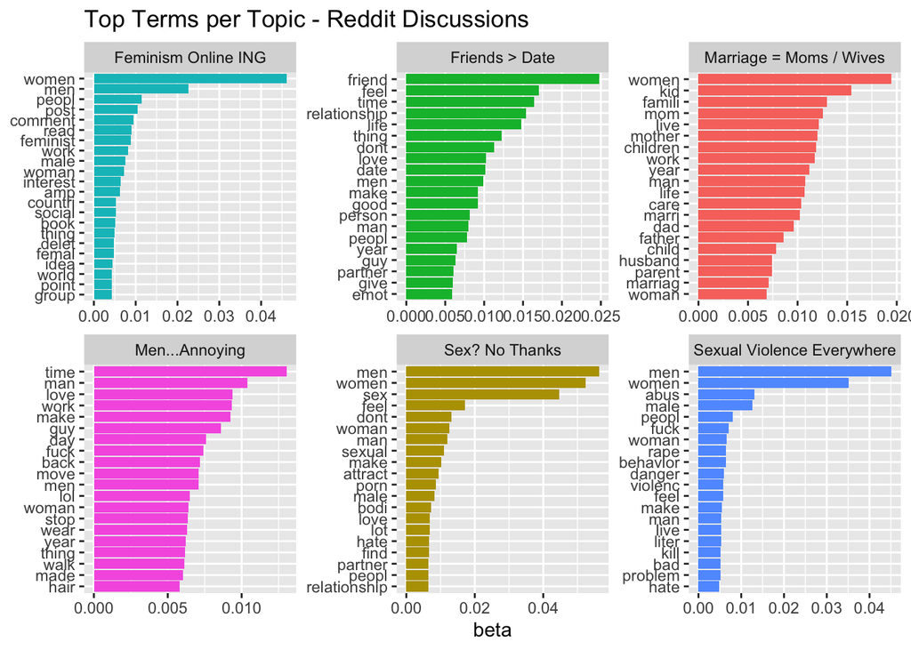

In the 4B movement subreddit, I found that people rarely talk about broader political or economic contexts. Instead, the discussions mostly focus on how women feel about sex, men, marriage, friendship, and feminism.

Many posts express the idea that men arenot attractive, that sex is often violent or abusive, and that friendship is more fun and meaningful than dating. Traditional marriage defines women as mothers and wives, which is being questioned. And there’s also a lot of participants on online feminism.

## Summary

My explanations for specific analysis can be found above with specific figures.

Here’s my main summary:

Mainstream media tends to frame the 4B movement as a short-lived reaction to the presidential election. They often portrayed 4B as a backlash by American feminists against Trump’s rise and his misogynistic policies, such as anti-abortion laws. The movement is frequently described as radical and extreme.

But when we look at online discussions, the 4B movement clearly goes far beyond that. The subreddit has over 24,000 members and produced 6,773 posts and comments between April 1 and May 1.

In online discussions, participants are not just reacting. They’re also actively redefining concepts like sex, romantic relationships, marriage, and motherhood. Those ideas were once considered as normal, desirable, and signs of success. But here, they were being reframed as part of a patriarchal system, which is male-centered, misogynistic, and exploitative of women’s labor and emotions. At the same time, words like friendship and feminism appear frequently, suggesting that many 4B participants are actively engaged with feminist thinking and they also value social lives centered around friendship rather than romance.

However, it’s undeniable that many posts associate men with negative terms like unattractive, dangerous, or violent.